# writeup

Kayla Johnson

September 18, 2020

# libraries

```r
library('dplyr')
```

# Introduction

Chances are, if you’re reading this, you are trying to make a quick buck. Maybe you need to buy a textbook for your math class. Or, maybe you want to treat your new friends to lunch at your favorite restaurant. Well, regardless of the reason that you’re trying to make money, you’re in the right place! After reading my blog, you’ll be well-equipped to make it big at the casino this weekend. I will teach you a little bit of statistics that will help you go a long way at the roulette wheel.

I will be using a programming environment, **R.Studio**, to simulate some of the same procedures that you will go through when you are at the casino. I will use simulation to understand how using my gambling strategy of choice, the **Martingale strategy**, impacts the profits/ losses at the roulette wheel. I will use a simulation to show how the money won/ lost varies over a series of plays. Also, I will use a simulation to find the number of plays before the game ends. Lastly, I will create a function that allows me to calculate earnings based on the changing of a single parameter.

## Background

Before we dive too deep into this lesson, I’d like to give you some important definitions. First, I should explain the game of roulette. On this roulette wheel there are 18 red portions of the wheel, 18 black portions of the wheel and 2 green portions of the wheel. Each portion of the wheel also has a number on it. Before each turn, a player places a bet on what a ball will land on. These bets can be made according to either colors or numbers. Next, I will explain the Martingale strategy. Even if you do not understand all of the code after this lesson, this strategy should be your key takeaway. If you play roulette with this strategy you have a good chance of walking away with some money (but don’t quit your day job, because the house always wins in the end). On the first round of the game place a $1 wager on red. If the ball lands on red, then $1 will be wagered on red once again. If the ball does not land on red, then the wager for the next play is twice times the amount of money lost on the previous play. These bets are made until a player reaches one of the three stopping rules included below.

### Stopping rules:

1. the player has **W** dollars. (W is the budget threshold for stopping.)
2. the player goes bankrupt.
3. the player completes **L** wagers (L is the maximum number of plays allowed)

# Methods

Here is the programming that was done to give you a better understanding of how the Martingale strategy works. Through this process we’ll be able to see how effective this strategy actually is. I’ll do my best at explaining my thought process while doing the work. First, I should define some very important variables that will be used.

## parameters are a list with the following entries:

**B** number, the budget **W** number, the budget threshold for successfully stopping **L** number, the maximum number of plays **M** number, the casino wager limit

## A single play with the Martingale strategy

The code below creates a function called one_play that takes **state** (the updated variables after the previous play) and shows what happens in a turn in the game. At each turn there will be a **proposed wager**. If the ball landed on red in the previous turn, then you should wager $1 on red. If the ball landed on black or green in the previous turn, then the wager should be two times the previous wager. The proposed wager is used to make the **actual wager**, but there are some instances when it is not the wager that is chosen. The actual wager is the minimum of the values for proposed wager, the casino’s wager limit (M), and the budget (B). If the proposed wager is higher than the casino allows, then it cannot actually be wagered. To simulate a spin of the wheel, the rbinom **red** was created. A **binomial distribution** is measured in terms of successes and failures. Our success with this strategy is landing on red (because we win money), and failure is landing on black or green (because we lose money). In a **single spin** we are hoping to see one observation of the color red. The probability of landing on red is 18/38, because 18 portions of the wheel are red and there are 20 portions that are green or black.The **state** variables update after each play. These variables are: the number of plays completed, the previous wager, and the budget. If you bet on red but land on black, then you lose what you wager. If you bet on red and land on red, then you win what you wager. The budget is adjusted based on how much money you have in your pocket.

```r
one_play <- function(state){
  # proposed wager is based on the previous play
    proposed_wager <- ifelse(state$previous_win, 1, 2*state$previous_wager)
  # actual wager is the minimum of the values for proposed wager, casino bet limit, and             budget.
    wager <- min(proposed_wager, state$M, state$B)
  # spin of the wheel:
    red <- rbinom(1,1,18/38)
# UPDATE STATE: the states of variables update after each play in roulette (starts at 0).
    #state of plays:
    state$plays <- state$plays + 1
    # state of previous wager: the wager becomes state$previous_wager after each play.
    state$previous_wager <- wager
    if(red){
    # WIN
      # if the roulette wheel lands on red, then the state of the budget is (the budget plus          what was wagered).
      # state$previous_win becomes true in this case.
      state$B <- state$B + wager
      state$previous_win <- TRUE
    }else{
    # LOSE
      # if the roulette wheel lands on black then the state of the budget is (the budget minus         what was wagered)
      # state$previous_win becomes false in this case.
      state$B <- state$B - wager
      state$previous_win <- FALSE
    }
  #returns the updated state list
  state
}
```

## When do we stop playing?

The code below creates a function **stop_play** that takes the **state** which was also used in the previous function (one_play) and determines if the gambler has to stop. There are three different scenarios where a gambler has to stop playing the game. First, they have to stop playing if the budget is equal to or less than zero. Second, they have to stop when they reach the limit for allowed plays. Third, they have to stop when they reach the casino’s winning threshold for stopping. If none of these criteria are met, a player can keep playing.

```r
# STOPPING RULE
stop_play <- function(state){
  # If the budget goes below $0 stop.
  if(state$B <= 0) return(TRUE)
  # If the number of plays gets to the limit of allowed plays stop.
  if(state$plays >= state$L) return(TRUE)
  # If the budget becomes more than the winning threshold for stopping stop.
  if(state$B >= state$W) return(TRUE)
  # Otherwise, keep on playing.
  FALSE
}
```

## An entire game of roulette

A series in this case is an entire game of roulette (all the plays from the start until a stopping rule is met). In our default settings for the games we will have a budget of 200 dollars **(B)**, the budget threshold for stopping is 300 dollars **(W)**, the maximum number of plays is 1000 **(L)**, and the casino wager limit is 100 dollars **(M)**. When a game first starts the initial state for the number of plays is always zero. The previous wager is also zero. The first bet will always be $1 too! **new_state** updates the state of the variables throughout the game. The new state is the state after an iteration of one play (one_play function from above). The new budget is added to a vector which contains the budgets from all previous plays. **get_last** tells us what the parameters are at the end of a simulation. Each time we run the series, the results replicate a new person playing the game.

```r
one_series <- function(
    B = 200
  , W = 300
  , L = 1000
  , M = 100
){
  # initial state
    #These are the initial states of all of the parameters.
    # Plays starts at zero
    # Previous wager starts at zero
    # Previous win equals TRUE, which makes the first bet $1.
  state <- list(
    B = B
  , W = W
  , L = L
  , M = M
  , plays = 0
  , previous_wager = 0
  , previous_win = TRUE
  )

  # vector to store budget over series of plays
  budget <- rep(NA, L)

  # For loop of plays
    # For the plays in the series of the first play to the last play
  for(i in 1:L){
    # the new state is the state after an iteration of one play (one_play function).
    new_state <- state %>% one_play
    # the updated budget is added to the budget vector
    budget[i] <- new_state$B
    #if the stop_play is TRUE
    if(new_state %>% stop_play){
      # return the budget vector for the series of all of the plays
      return(budget[1:i])
    }
    # returns state list with values updated based on the previous play
    state <- new_state
  }
  budget
}

# get the last parameters
  #Tells you what the parameters are at the end of a simulation.
get_last <- function(x) x[length(x)]
```

### Let’s visualize it!

I’m sorry if this blog is getting lengthy, but we’re getting to the fun part! Creating plots for a couple series will give us a better understanding of what it actually looks like to play a game with the Martingale strategy. I will show how this strategy works for two different people. Both players start with $200, but they have very different outcomes. Player one is rather unfortunate and loses their money in only eight plays. Player two, however, has a very interesting game. The amount of money they have fluctuates throughout the game, but in the end they leave the casino with 300 dollars. Player two kept playing even when it seemed like they were losing too much money. Sometimes it pays to be patient!

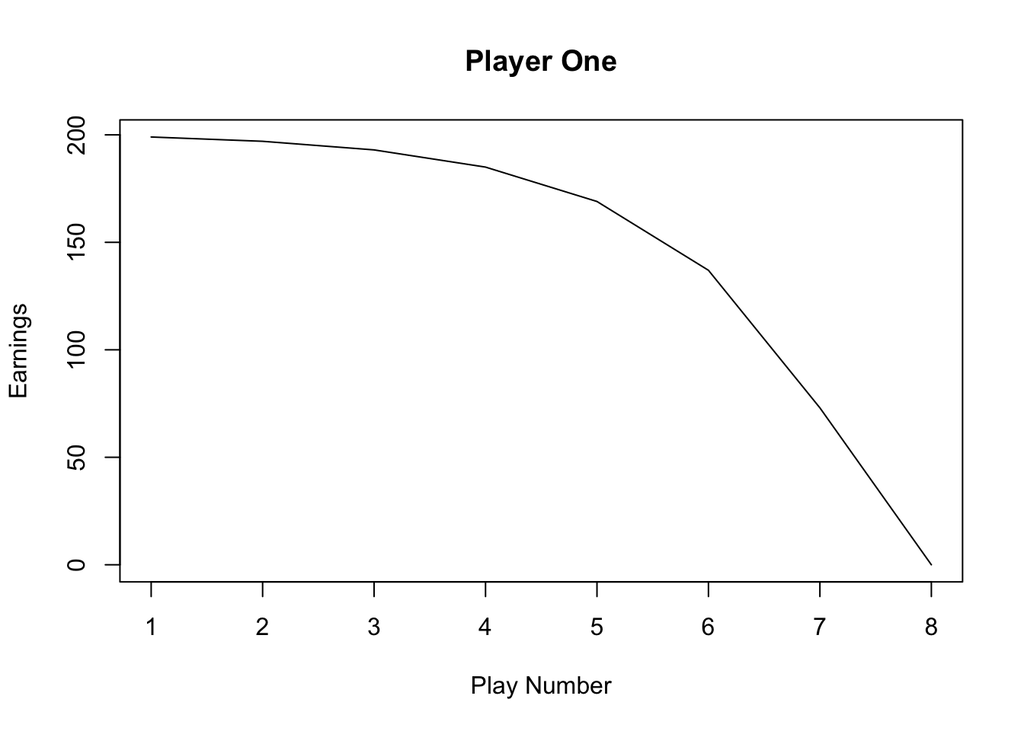

```r
#Person one's plot
  set.seed(9)
  one_person_plays <- one_series(B = 200, W = 300, L = 1000, M = 100)

plot(c(1:length(one_person_plays)), y= one_person_plays, type = "l", main= "Player One", xlab= "Play Number", ylab = "Earnings")
```

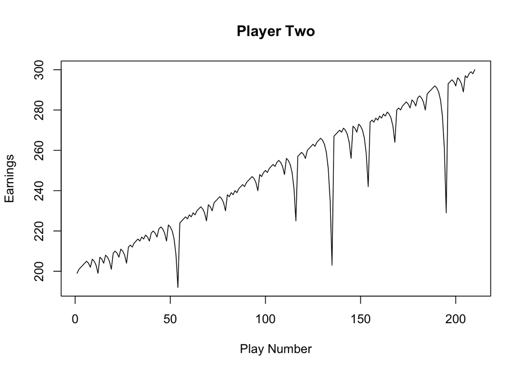

```r
#Person two's plot
  set.seed(89)
  one_person_plays <- one_series(B = 200, W = 300, L = 1000, M = 100)

plot(c(1:length(one_person_plays)), y= one_person_plays, type = "l", main= "Player Two", xlab= "Play Number", ylab = "Earnings")
```

## Simulation 1: Money earned in many games of roulette

A simulation will show the outcome of many games of roulette. First, we can simulate the amount of money that different players walk out with when using the Martingale strategy. To simulate multiple games, we use a for loop (which repeats the process that we used for one game). When we run **walk_out_money** we see that players are only ever walking out with 300 dollars or 0 dollars. When the casino play limit is 1000 it looks like gamblers either stop playing because they lose all their money or because they won the maximum amount of money (you can also see this in the histogram below). Maybe this is the parameter that we can change to see more varied results.

```r
# Simulation
  # This is the simulation for the amount of money a player walks out with after using the martingale strategy
walk_out_money <- rep(NA, 100)
for(j in seq_along(walk_out_money)){
  walk_out_money[j] <- one_series(B = 200, W = 300, L = 1000, M = 100) %>% get_last
}
walk_out_money
```

```
##   [1] 300 300 300 300   0   0 300   0   0 300   0   0   0   0 300   0   0   0
##  [19]   0   0   0 300 300 300 300 300 300   0   0 300 300   0 300 300 300 300
##  [37] 300   0 300 300   0 300   0 300 300 300 300   0 300 300 300   0 300 300
##  [55] 300   0 300 300   0   0 300   0   0   0   0   0   0   0   0   0 300   0
##  [73]   0   0   0 300 300 300   0 300 300 300 300 300   0   0 300 300 300 300
##  [91]   0   0 300   0 300 300   0 300 300 300
```

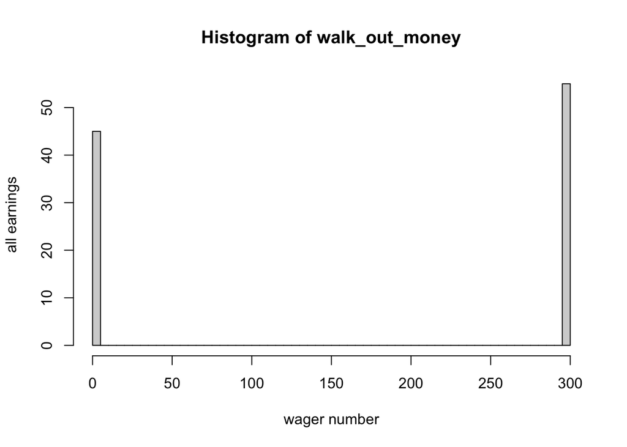

```r
# Walk out money distribution
hist(walk_out_money, breaks = 100, xlab = "wager number", ylab = "all earnings")
```

```r
# Estimated probability of walking out with extra cash after using the Martingale strategy.
mean(walk_out_money > 200)
```

```
## [1] 0.55
```

```r
# Estimated earnings
  # This is the average amount of money made after using the Martingale strategy.
mean(walk_out_money - 200)
```

```
## [1] -35
```

## Simulation 2: Number of plays before stopping in many games of roulette

A simulation can also used be to show the number of games that gamblers play before stopping. With **number_plays** we used almost the same code that we used to find **walk_out_money**, but an important addition is that we add **length()** to the end. This gives us the total number of plays in each game of roulette.The average number of plays is less than 1000. It is rare for someone to have to stop playing roulette because they have reached the maximum number of plays **(L)**. As you can see from the plot, the number of plays changes a lot from game to game. We can create a **histogram** to more easily see the distribution of the number of plays. The most amount of gamblers play around 200 games before stopping.

```r
# Simulation
  #Used to find the number of plays before stopping in each iteration of the simulation
  #the length of the simulation used previously gives the number of plays
number_plays <- rep(NA, 100)
for(j in seq_along(number_plays)){
  number_plays[j] <- one_series(B = 200, W = 300, L = 1000, M = 100) %>% length()
}
#Average number of plays
mean(number_plays)
```

```
## [1] 201.71
```

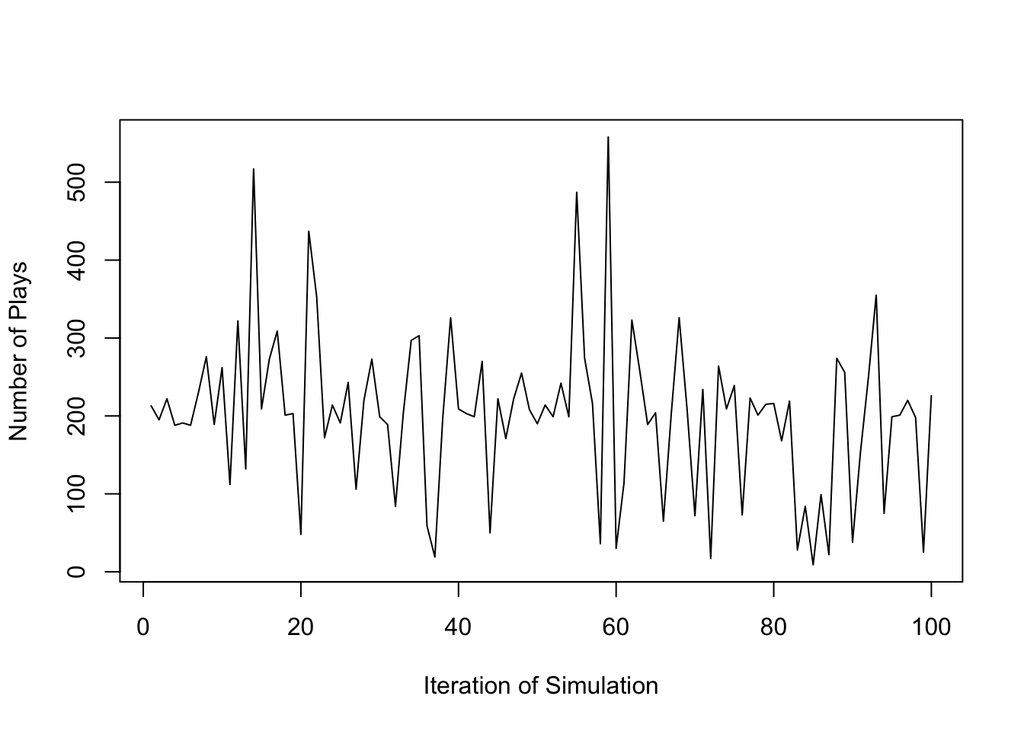

```r
#creates a plot that shows the number of plays for each iteration of the simulation
set.seed(83)
plot(number_plays, type = "l", xlab= "Iteration of Simulation", ylab= "Number of Plays")
```

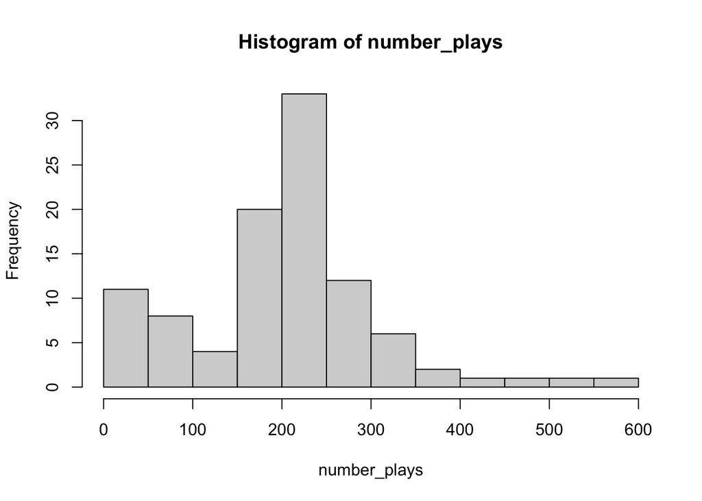

```r
#number of plays distribution
hist(number_plays, breaks = 10)
```

## Simulation 3: Changing the wager number limit (L)

I can also create a simulation that shows how changing the maximum allowed plays (L) changes the average earnings for gamblers. We do this by creating a vector called **max_plays** which contains a sequence of max plays from 10 to 1000. The max plays increase by 10. This vector is inputted into **walk_out_money**, so we can see the impact the change has on average earnings. With the plot below, we can see that there are not many scenarios (based on changing the parameter L) where the average earnings are positive.

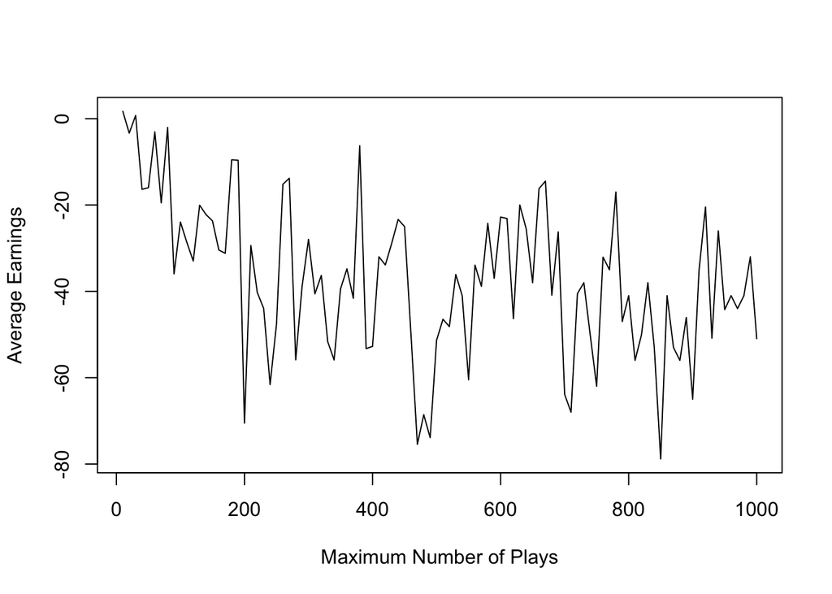

```r
# Changing a parameter
 #Vector for limit signifies different values for the wager number limit allowed by the casino.
max_plays = seq(10, 1000, by =10)
avg.earn = NA

 #Function that shows that the earnings change as the wager number limit changes.
for(i in c(1:length(max_plays))){
  walk_out_money<- rep(NA, 100)
  for( j in seq_along(walk_out_money)){
    walk_out_money[j] <- one_series(B = 200, W = 300, L = max_plays[i], M =100) %>% get_last
 }

#Estimated Earnings
avg.earn[i] = mean(walk_out_money - 200)
}

plot(x= max_plays, y= avg.earn, type= "l", xlab= "Maximum Number of Plays", ylab= "Average Earnings")
```

Changing the value of **L** is not that helpful, but I hope to explore the Martingale strategy more in the future. College is hard, and I know if I find the best parameters for the Martingale strategy I will be able to help so many people make money.

# Conclusions

Before I did this simulation, I did not know a lot about the game of roulette. Also, I was just introduced to the Martingale strategy. Now I know that manipulating the parameters is essential when using this strategy, because it impacts the probability of walking away with money. Although we cannot change the parameters set by the casino (in this case we have **M** which is the casino’s wager limit), we can change the variables that we have control of (like **L** which is the number of plays allowed and **W** which is the budget threshold for stopping). Manipulating these variables can lead to a greater chance of success.

# Limitations

The parameter **L** limits the amount of money that a player walks out with. If a player stops because they have reached their limit for the number of plays, then that means that they did not go bankrupt or reach the budget threshold for stopping. They are somewhere in between. If **L** is a large number, then a player will likely stop because of another stopping rule. However, if **L** is small (for example L=15) then a player is going to have to stop playing because of this parameter. They will not reach the budget threshold for stopping, because it is not possible to win that much money in so little plays.

The best scenario seems to be around 10 total plays. This is the number of plays that gives you earnings that are close to $0. Hey that’s better than losing money! If you only care about making money, I am **so** sorry to disappoint you! If you believe that the real treasure is the friends you made along the way, thank you for coming to my blog. I hope to see you again soon!